# Prosper Loan Data Analysis by Jenny Hung

## Overview

In this project, we analyze the Propser Loan dataset. Our goal is to explore the data and discover patterns and relationships between selected variables - from an investor or lender’s perspective.

Our goal for the project is to answer the following questions:

1. What are the factors that influences the BorrowersRate
2. What are the factors that influences the LendersYield
3. What are the relationship between Employement status and Lender’s Yield
4. What are the relationship between lendersYield, credit rating and number of recommendations
5. What about impact of job or ownership’s on loan status, borrowers rate, and status

Before we continue, we first load the data and explore the structure of the data set and nature of variables. We see that the data set has 81 variables and contains 113,937 data points.

## Univariate Plot Section

The following table shows the distribution of BorrowerRate.

```
##    Min. 1st Qu.  Median    Mean 3rd Qu.    Max.
##  0.0000  0.1340  0.1840  0.1928  0.2500  0.4975
```

The following table shows the distribution of LenderYield.

```
##    Min. 1st Qu.  Median    Mean 3rd Qu.    Max.
## -0.0100  0.1242  0.1730  0.1827  0.2400  0.4925
```

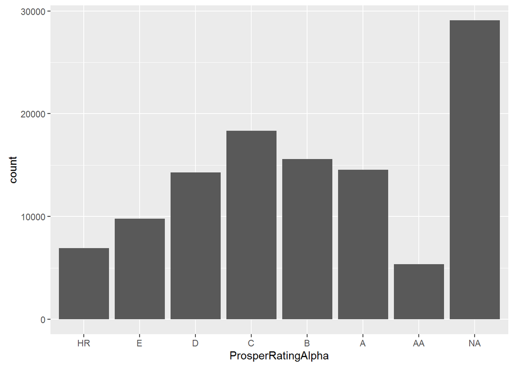

We see that where actual credit rating exists, ProsperRatingAlpha is approximately normally distributed. Note that there are quite a few data points where the Prosper Rating is not available (as observed in NA values).

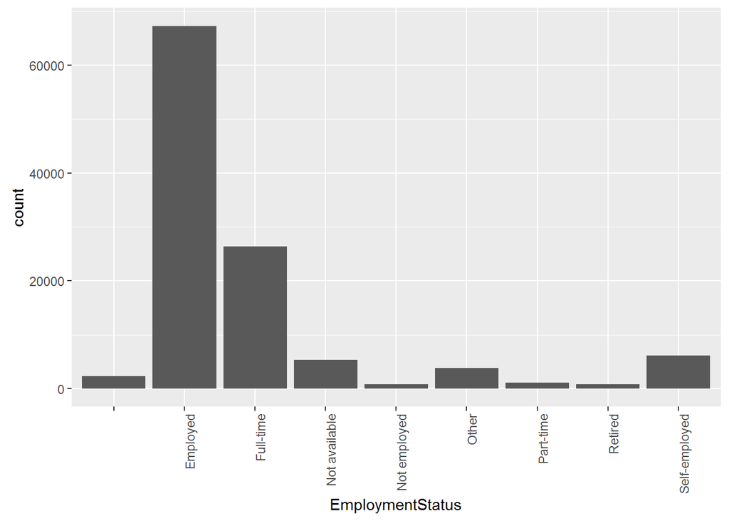

```r
summary(loan$EmploymentStatus)
```

```
##                    Employed     Full-time Not available  Not employed
##          2255         67322         26355          5347           835
##         Other     Part-time       Retired Self-employed
##          3806          1088           795          6134
```

Most of the loans borrowers are employed.

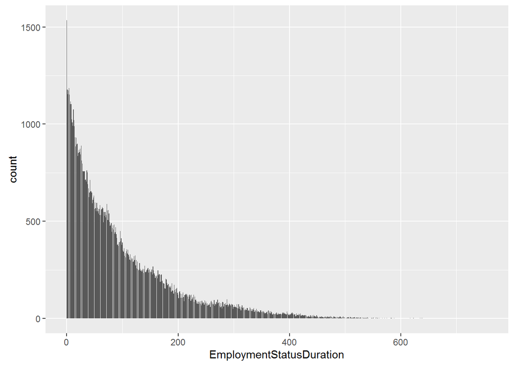

```
##    Min. 1st Qu.  Median    Mean 3rd Qu.    Max.    NA's
##    0.00   26.00   67.00   96.07  137.00  755.00    7625
```

Even though a vast majority of loans has Employed as Employment Status, the employement duration in number of days is not normally distributed. In fact, it is skewed with a long right tail.

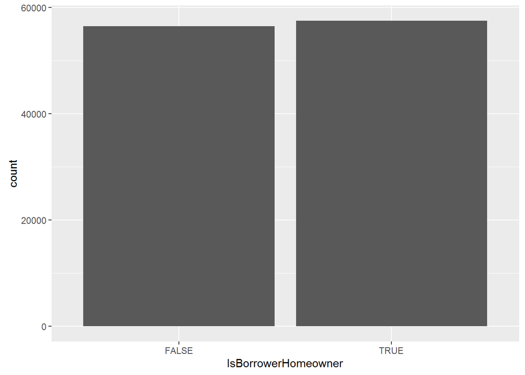

The home ownership status for successful loan appicants is approximately equally distributed.

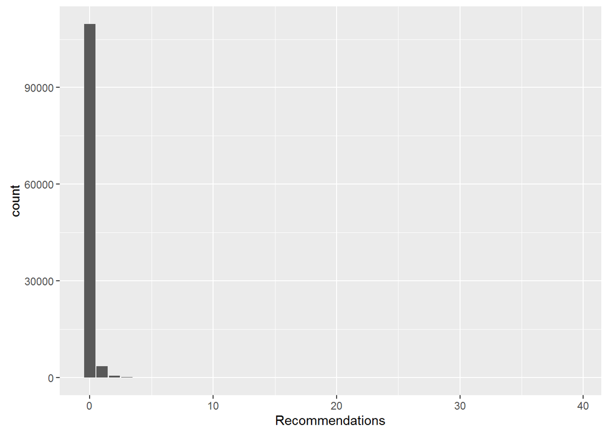

```
##     Min.  1st Qu.   Median     Mean  3rd Qu.     Max.
##  0.00000  0.00000  0.00000  0.04803  0.00000 39.00000
```

When looking at how many recommendations each loan received, we see that most of the loans received no recommendations. Note that this is the number of recommendations a borrower received at the time when the loan was created or listed.

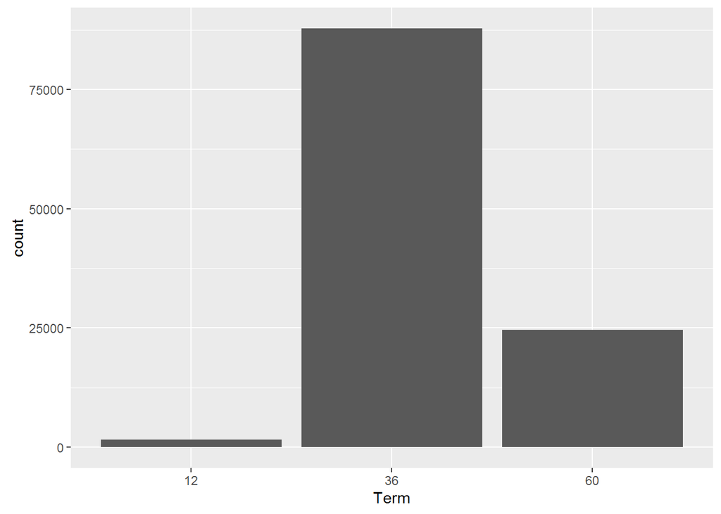

Most of the loans are of 36-month term.

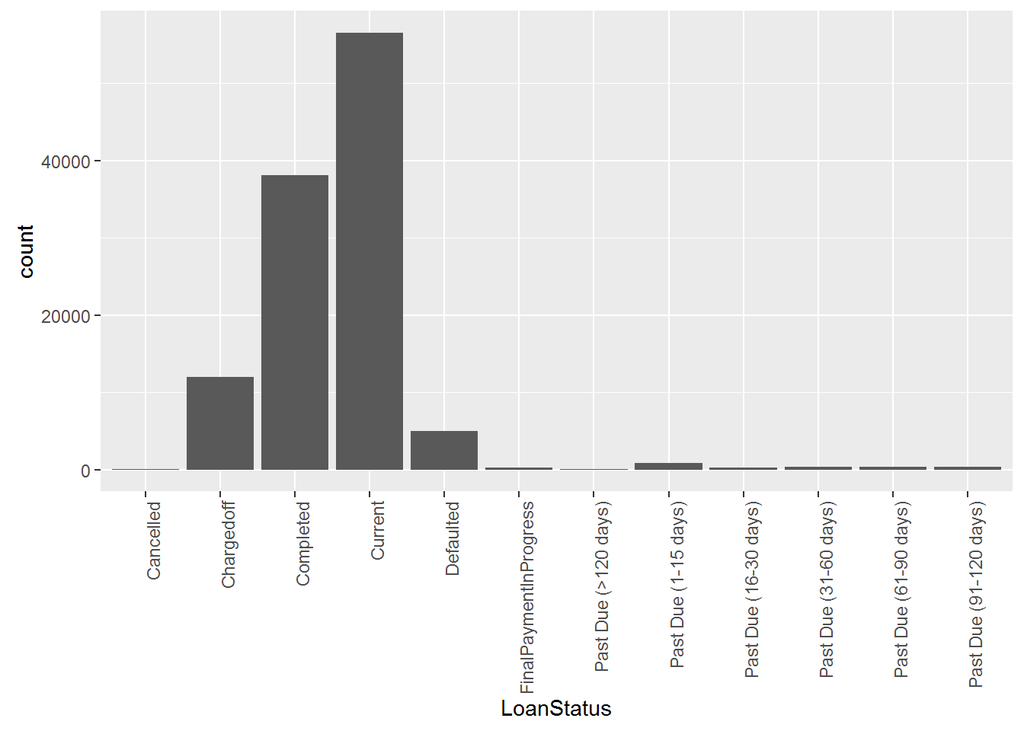

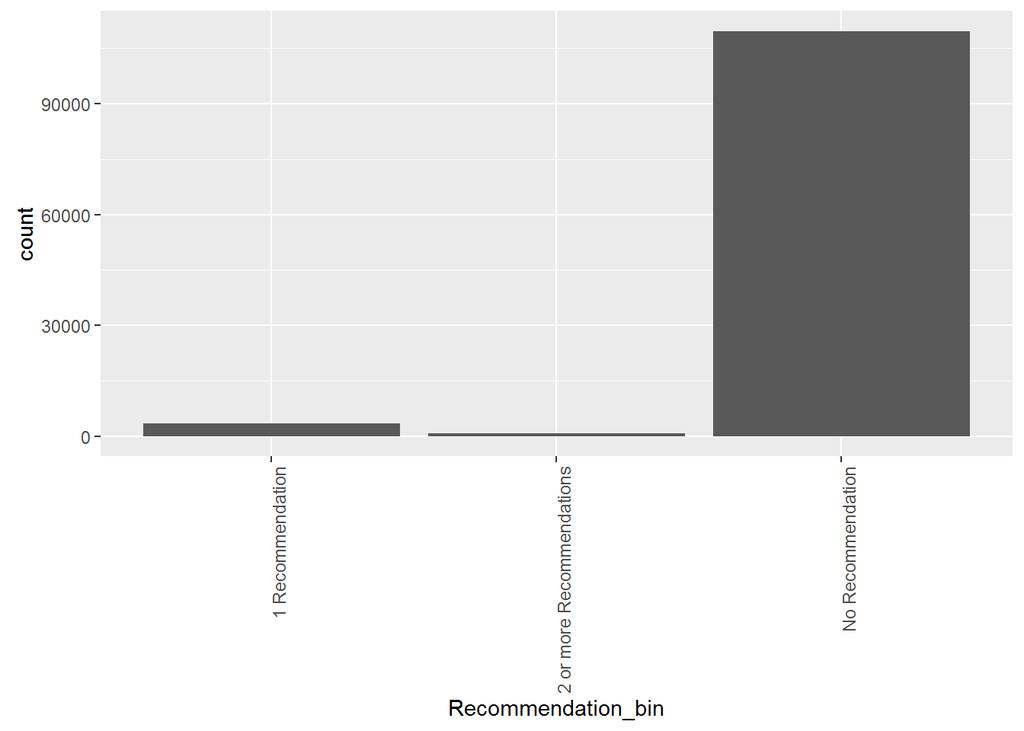

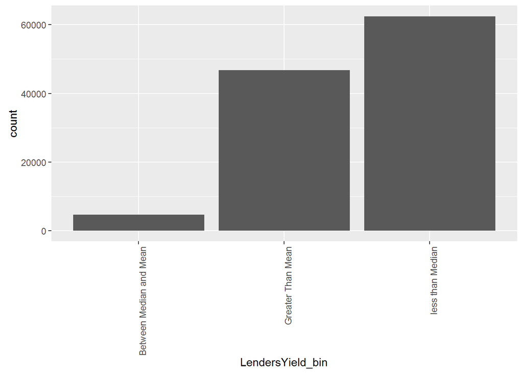

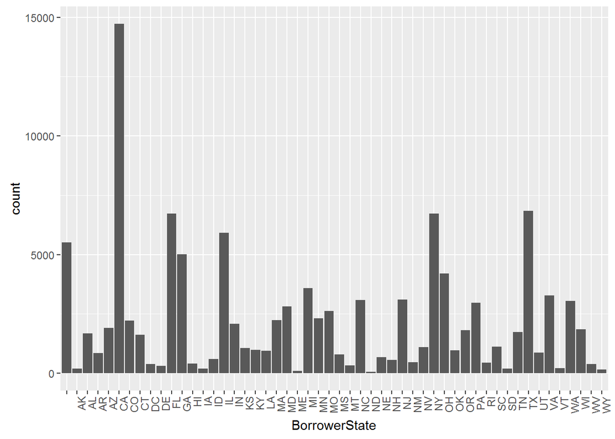

## Univariate Analysis

### Structure of data set

There are 113,937 loans in the data set and 81 features. Of the 81 features, The ProsperRating, which comes in two flavors, ProsperRatingAlpha and ProsperRatingNumeric, are both Prosper’s own credit reporting scale, and it has the following structure:

- ProsperatingNumeric: 0, 1, 2, 3, 4, 5, 6, 7 (No credit rating, worst credit —> best credit)
- ProsperatingAlpha: N/A, HR, E, D, C, B, A, AA (No credit rating, worst credit —> best credit)
- BorrowerRateThe Borrower’s interest rate for this loan.
- LenderYield: The Lender yield on the loan. Lender yield is equal to the interest rate on the loan less the servicing fee.

Other observations:

- Most loas are of 36-month term.
- Most laon applicant are employed.
- Approximately half of loan applicants are also home owners.
- Most of the loan applicants have received no recommendations.
- Mean BorrowRate is 19.28%.
- Mean LenderYield is 18.27%.

### Main feature of interest

Due to the large number of variables, I have chosen to focus on `BorrowerRate`, `LendersYield`, `Term`, `ProsperRatingNumeric`/`ProsperRatingAlpha`, `Recommendations`, `DebtToIncomeRatio`, `StatedMonthlyIncome`, and `MonthlyLoanPayment`.

### Any created or constructed features

`BorrowerRate` is bucketed. This allowed me to see the distributions of these two variables more easily. Bucketing (binning) was done on each loan to show whether or not the interest loan of the loan is below the median of all loans, between the median and the mean of all loans, or above the mean of all loans. In addition, the number of recommendations is also bucketed. Loans that have no recommendations fall into one bin, and loans with exactly one recommendation fall into another bucket, and loans with with more than one recommendations form yet another bucket.

In addition, `PaymentIncomeRatio` is also constructed which is a ratio of `MonthlyLoanPayment` over `StatedMonthlyIncome`.

Careful exmination revealed that the missing values contained in the data set can be disregarded as they are most likely to be missing completely at random for the varialbes that are considered in the preceeding paragraph. This is because the nature of data set (a set of succesfuly approved loans) and their presence does not depend on observed or unobserved measurements of other features considered.

## Bivariate Plot Section

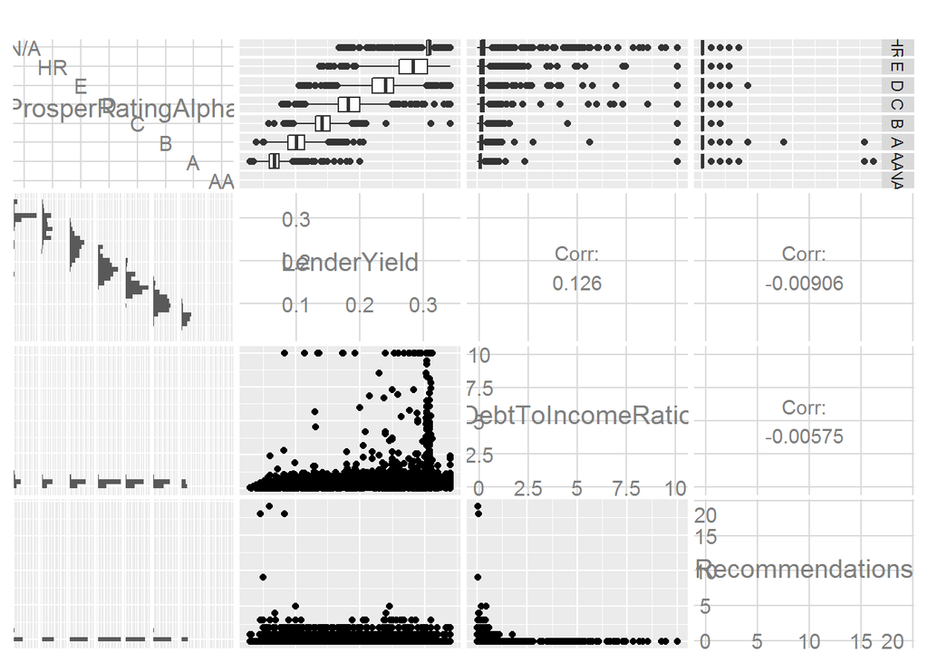

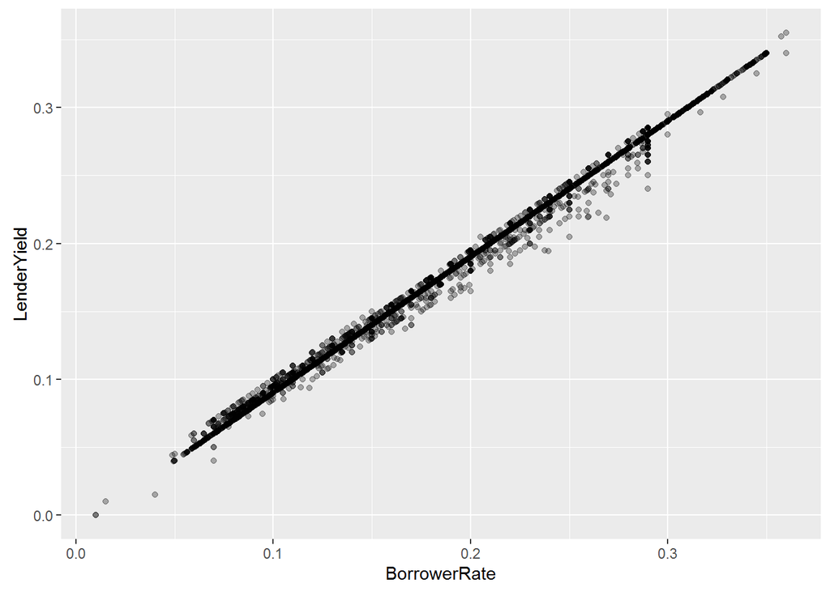

Not surprisingly, the scatter plot of BorrowerRate and LenderYield approximately fall on a stright line passing through the origin. The following calcualtion also show that these two variables are of perfect correlation.

```r
with(loan, cor.test(BorrowerRate, LenderYield))
```

```
##
##  Pearson's product-moment correlation
##
## data:  BorrowerRate and LenderYield
## t = 8493.938, df = 113935, p-value < 2.2e-16
## alternative hypothesis: true correlation is not equal to 0
## 95 percent confidence interval:
##  0.9992021 0.9992204
## sample estimates:
##       cor
## 0.9992113
```

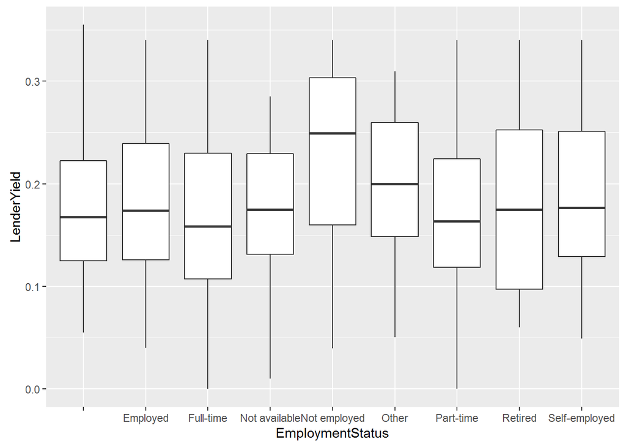

Borrowers who are unemployed tend to pay the highest interest rate on average.

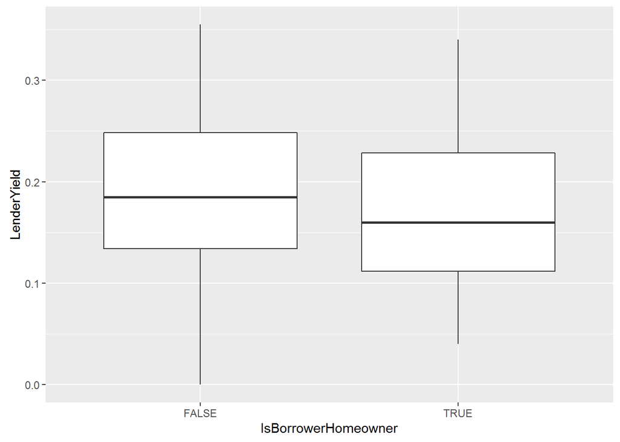

Borrowers who are not home owners also tend to pay higher interest rate.

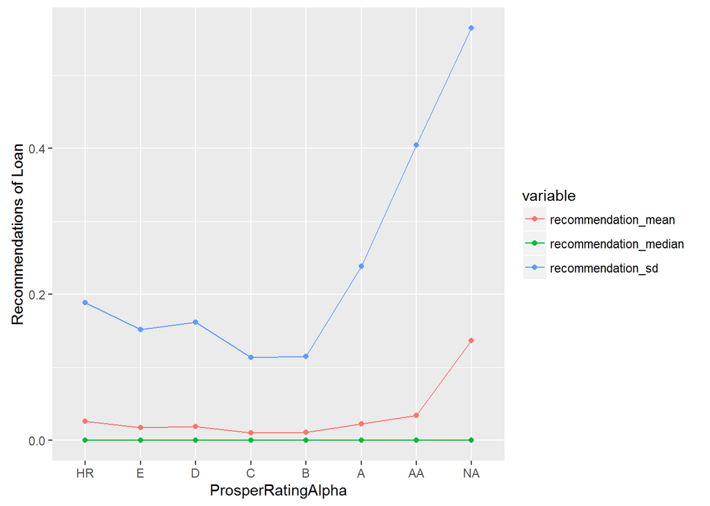

The above graph shows the relationship between the credit rating of the borrowed against the number of recommendations that a borrower received for the loan. The mean, median as well as standard deviation of the number of recommendations are shown. Not surprisingly, the median recommendation is most robust, as it barely moved at all, whereas the mean had shifted based on the credit raitng of the borrower.

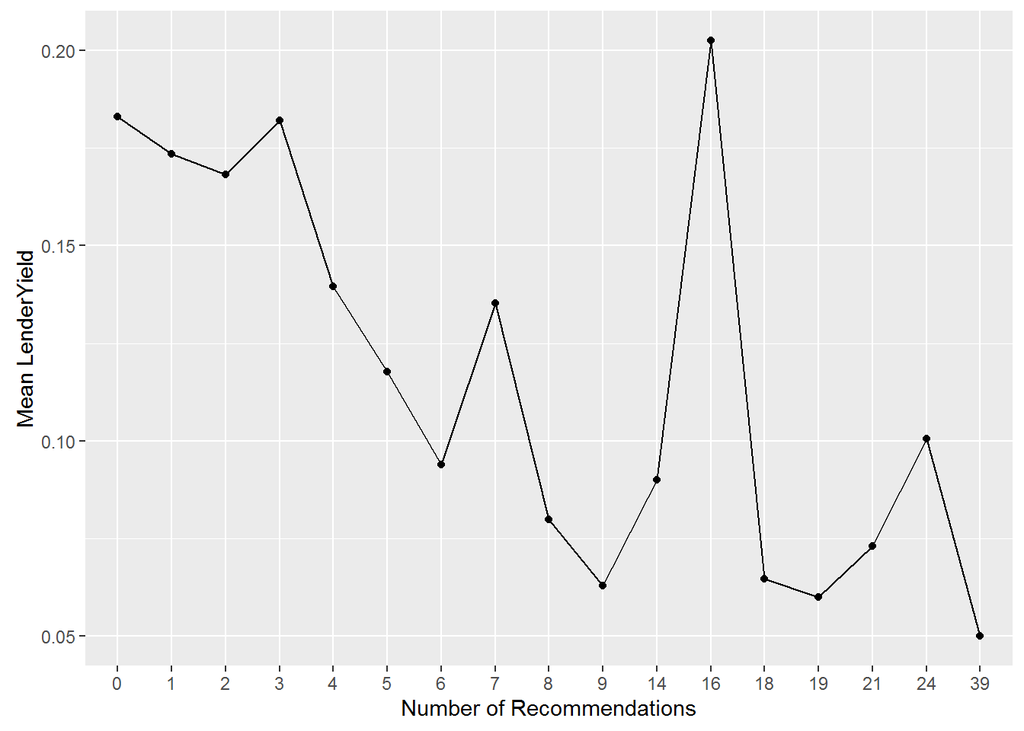

The above graph shows the relationship between the numeber of recommendations vs. the mean LendersYield. The relationship between LenderYield and number of recommendations is not monotonic.

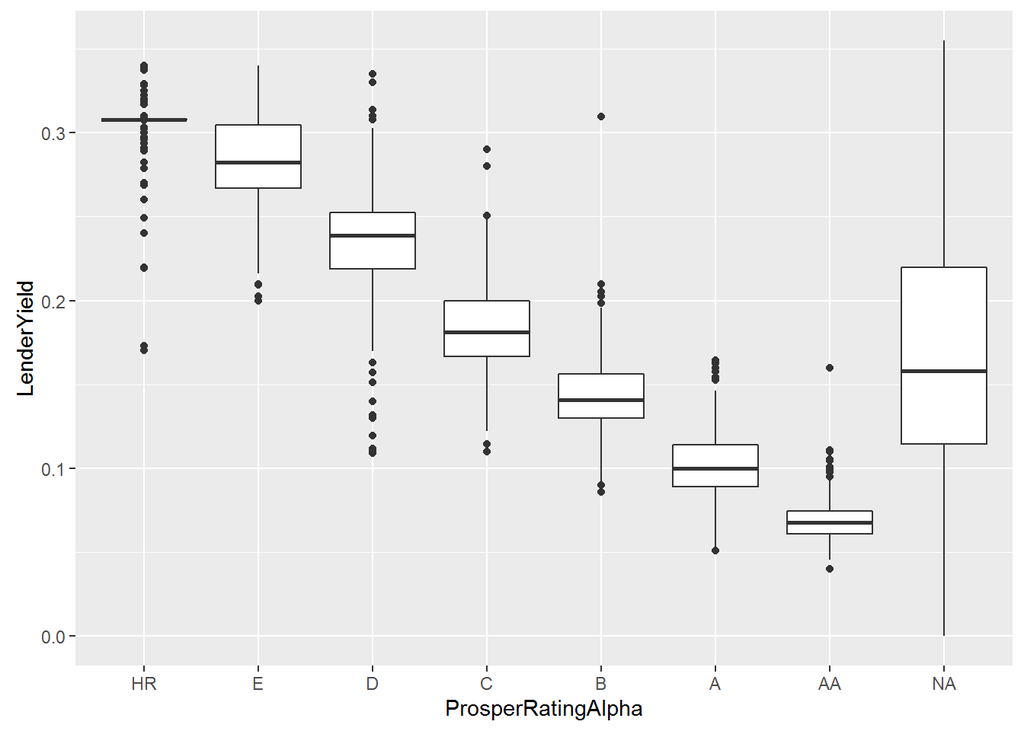

The above plot shows the overall relationship between a borrowers credit rating and the interest rate the corresponding lender receives. In general, the lender’s yield decreases as the credit rating improves. Where there is no established credit rating, there is also a large variabiltiy in the lenders yield.

## Bivariate Analysis

### Major relationships observed

- There is a near perfect correlation between BorrowerRate and LenderYield.
- In general, `BorrowerRate` is inversely proportional to the credit rating of a borrower. Given the near perfect correlation, this also means that `LenderYield` is inversely proportional to the credit raitng of a borrower.
- In cases where a borrower has no established credit rating (namely, where `ProsperRatingNumeric` or `ProsperRatingAlpha` is NA), the LenderYield tend to be somewhere in between the interest rates for the loans with the best credit and with the worst credit.

### Surprising finding

- Previously, I had conjectured that the LendersYield is correlated to the number of recommendations that a borrower receives. However, this prior belief does not bear out in the exploratory analysis. In fact, the type of borrowers who receive the highest number of recommendations is one that does not have a credit rating, followed immediately by borrowers who have the best credit rating.

### The strongest relationship

- The strongest relationship found is the invserse relationship between the interest rate at which a borrower pays and the borrower’s credit strength.

## Multivariate Plot Section

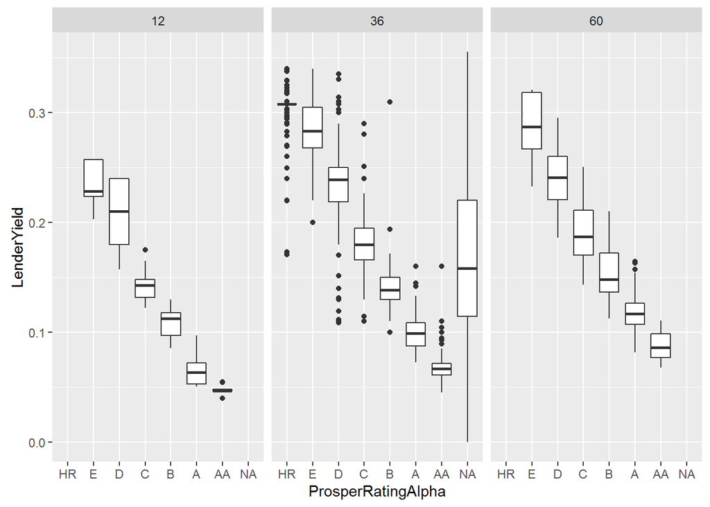

```r
## Investigate the relationship between LendersYield and DebtIncome ratio
## Find correlation r - low
with(loan, cor.test(DebtToIncomeRatio, LenderYield))
```

```
##
##  Pearson's product-moment correlation
##
## data:  DebtToIncomeRatio and LenderYield
## t = 20.1467, df = 105381, p-value < 2.2e-16
## alternative hypothesis: true correlation is not equal to 0
## 95 percent confidence interval:
##  0.05592580 0.06795465
## sample estimates:
##        cor
## 0.06194247
```

The correlation between `DebtToIncomeRatio` and `LenderYield` is low. However, I suspect this is becuase the correlation is confounded by the different credit ratings. The next plot explores this possibility

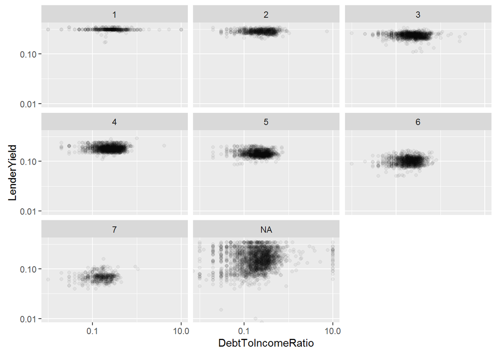

In the proceeding graph, we show the relationship between `DebtToIncomeRatio` and `LenderYield` across all `PropserRatingNumeric` (credit ratings). We have also performed feature transformation and show the graph on a log-log basis. To make the graph more easily readable, we have shown the graph on a subset of the loan data but the relationship is representative to the entire dataset due to the randomization of the seletion process.

Note that as the scatter at the bottom left corner represent the cluster of loans with the lowest `DebtToIncomeRatio` and the lowest `LenderYield`. As the scatter moved upwards, it indicates that `LenderYield` is also moving higher. Note that the cluster of points indicating no credit ratings have the highest level of variability.

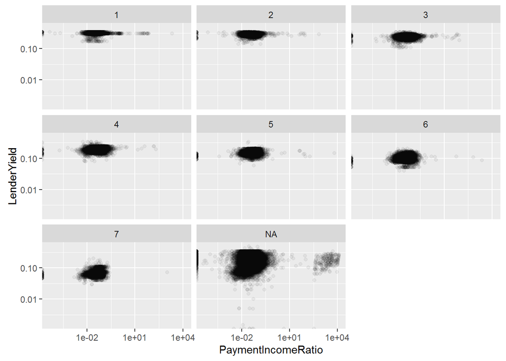

We see similar trend when looking at the relationship between LenderYield nd PaymentIncomeRatio.

In the proceeding graph, we show the relationship between PaymentIncomeRatio and LenderYield across all PropserRatingNumeric (credit ratings). We have also performed feature transformation and show the graph on a log-log basis. To make the graph more easily readable, we have shown the graph on a subset of the loan data but the relationship is representative to the entire dataset due to the randomization of the seletion process.

Note that as the scatter at the bottom left corner represent the cluster of loans with the lowest `PaymentIncomeRatio` and the lowest `LenderYield`. As the scatter moved upwards, it indicates that `LenderYield` is also moving higher. Note that the cluster of points indicating no credit ratings have the highest level of variability.

```r
## Conclude whether DebtIncome ratio is highly correlated with PaymentIncoem ratio
## Find correlation r
with(loan, cor.test(DebtToIncomeRatio, PaymentIncomeRatio))
```

```
##
##  Pearson's product-moment correlation
##
## data:  DebtToIncomeRatio and PaymentIncomeRatio
## t = 229.953, df = 105367, p-value < 2.2e-16
## alternative hypothesis: true correlation is not equal to 0
## 95 percent confidence interval:
##  0.5740264 0.5820672
## sample estimates:
##       cor
## 0.5780608
```

## Multivariate Analysis

```r
mod = lm(LenderYield~ProsperRatingNumeric + EmploymentStatus + EmploymentStatusDuration +
                      IsBorrowerHomeowner+Term+Recommendations + DebtToIncomeRatio +PaymentIncomeRatio,
          data=loan)
```

## Final Plots and Summary

### Plot One

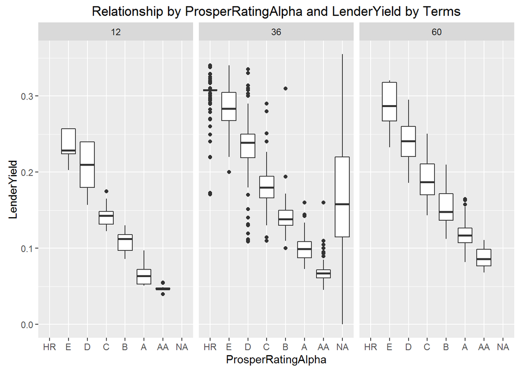

### Plot Two

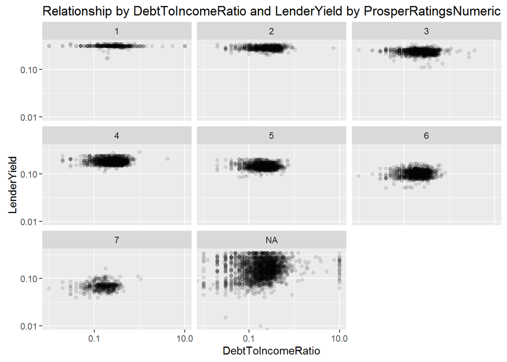

### Description Two

In the proceeding graph, we show the relationship between DebtToIncomeRatio and LenderYield across all PropserRatingNumeric (credit ratings). We have also performed feature transformation and show the graph on a log-log basis. To make the graph more easily readable, we have shown the graph on a subset of the loan data but the relationship is representative to the entire dataset due to the randomization of the seletion process.

Note that as the scatter at the bottom left corner represent the cluster of loans with the lowest `DebtToIncomeRatio` and the lowest `LenderYield`. As the scatter moved upwards, it indicates that `LenderYield` is also moving higher. Note that the cluster of points indicating no credit ratings have the highest level of variability.

### Plot Three

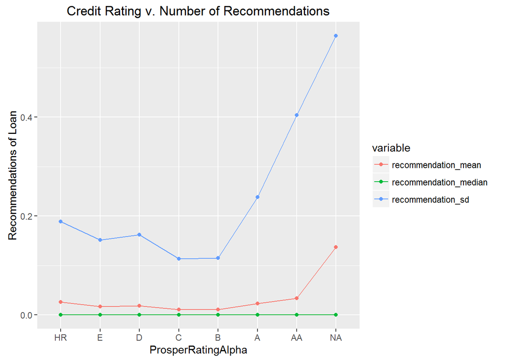

### Description Three

The above graph shows the relationship between the credit rating of the borrowed against the number of recommendations that a borrower received for the loan. The mean, median as well as standard deviation of the number of recommendations are shown. Not surprising, the median recommendation is most robust, as it barely moved at all, whereas the mean had shifted based on the credit raitng of the borrower.

## Conclusion and Summary

Some limitations of this model include the source of the data. Given that the loan data only contains loans that have been succesfully approved, my exploration and analysis is limited to the loans that have already passed the first funding test. In other words, we do not have data to answer find out the true pattern between Credit Rating, Employement Status, Home Ownership, and Debt to Income ratio and how these factors impact the loan’s chances of being aproved. Therefore, my view is that a more interesting question is how these factors affect the chances of how likely an application gets funded. A more complete data set would be crucial to faciliate this analysis.